# Automating Your Academic CV, Biosketch, and Website with R

CCHMC R Users Group

Cole Brokamp

2022-09-14

## 👋 Welcome to the CCHMC R Users Group (RUG) Meeting

- [join](https://teams.microsoft.com/l/team/19%3av1u66Cu-BwAAFxcsoevFL_WRazFHW6P2btSKiIxtc4s1%40thread.tacv2/conversations?groupId=27d06cf9-ea00-4d0a-b17c-1bdf4f63fb8f&tenantId=680254d4-278b-4aa1-aca8-c2600f79c533) the MS Team: `bxm5jq1` <sup>1</sup>
- presentations and code: https://github.com/CCHMC-RUG
- events: MS Teams, emails, Outlook events
- please share and consider presenting
[^1]: Click “Join or create a team below your teams” list and look for the “Join a team with a code” card

## Why Automate?

- automating a manual process is what data people do!
- information in your CV is *data* and can be extracted for different purposes (CV/resume, biosketch, website)
- adapt to changing formatting requirements by changing code, not data
- don’t “lock yourself in” by using a specific online service or closed source software
- use links on [website](https://colebrokamp.com/cole-brokamp-cv.pdf) (or [with people that need](https://raw.githubusercontent.com/cole-brokamp/biosketch/master/cole-brokamp-nihbiosketch.pdf)) to access your biosketch, CV

## Existing Packages for R

### `datadrivencv`

- https://github.com/nstrayer/datadrivencv
- https://github.com/shaziaruybal/automate-cv-rmd

### `vitae`

- https://pkg.mitchelloharawild.com/vitae

## Let’s Build Our [Own](https://github.com/cole-brokamp/colebrokamp.com)

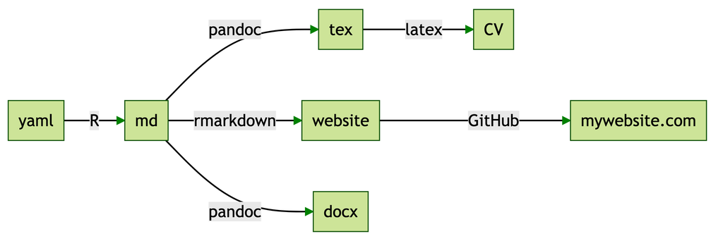

CV Automation Workflow

## YAML Ain’t Markup Language (YAML)

[YAML](https://yaml.org/) is a human- *and* machine-readable data-serialization language for *all* programming languages.

- list structure often used for configuration files
- whitespace indentation – spaces not tabs! – specify the structure
- [YAML reference card](https://yaml.org/refcard.html)
- R (Studio?) seemingly favors `yaml` over `json`

## `pubs.yaml`

```yaml
pennington-2022:
  title: "Racial Fairness in Precision Medicine: Pediatric Asthma Prediction Algorithms"
  author: Jordan Pennington, Erika Rasnick, Lisa J. Martin, Jocelyn M. Biagini, Tesfaye B. Mersha, Allison Parsons, Gurjit K. Khurana Hershey, Patrick Ryan, Cole Brokamp
  journal: American Journal of Health Promotion
  issue_pages: Online
  year: 2022
  doi: 10.1177/08901171221121639

esteban-2022:
  title: "Understanding Racial Disparities in Childhood Asthma Using Individual- and Neighborhood-Level Risk Factors"
  author: Esteban Correa, Lili Ding, Andrew F. Beck, Cole Brokamp, Mekibib Altayeb, Robert S. Kahn, Tesfay Mersha
  journal: Journal of Allergy and Clinical Immunology
  issue_pages: In Press
  year: 2022
  doi: 10.1016/j.jaci.2022.07.024

brokamp-2022:
  title: "A High Resolution Spatiotemporal Fine Particulate Matter Exposure Assessment Model for the contiguous United States"
  author: Cole Brokamp
  journal: Environmental Advances
  issue_pages: "7:100155"
  year: 2022
  doi: 10.1016/j.envadv.2021.100155
```

## `talks.yaml`

```yaml
PAS-2022:
  title: "Decentralized Geomarker Assessment for Multi-Site Studies"
  event: Pediatric Academic Societies Annual Meeting
  year: 2022
  location: Denver, CO

NIH-2022:
  title: "Challenges and Solutions for Private and Reproducible Environmental Exposure Assessment at Scale"
  event: NIH Ethical, Legal, and Social Implications of Gene-Environment Interaction Research Workshop
  year: 2022
  location: Online
  download_link: "https://colebrokamp-website.s3.amazonaws.com/talks/GxE_ELSI_Brokamp.pdf"
```

## Use R to create markdown files

```r
yaml::yaml.load_file("pubs.yaml") |>
  purrr::modify(
    ~ glue::glue(
      .x = .,
      "{author}. {title}. *{journal}*. {issue_pages}. {year}."
    )
  ) |>
  purrr::modify(
    ~ gsub(
      x = .,
      pattern = "Cole Brokamp",
      replacement = "**Cole Brokamp**"
    )
  ) |>
  paste(collapse = "\n\n") |>
  cat(file = "pubs.md")
```

## Use R to create *complicated* markdown files

https://github.com/cole-brokamp/support/blob/main/parse_support.R

## Pandoc

Convert markdown to tex file:

```bash
pandoc -o pubs.tex pubs.md
```

Convert markdown to MS Word file using a reference document:

```bash
pandoc pubs.md --reference-doc=reference.dotx -o pubs.docx
```

## CV

Write [CV in LaTeX](https://github.com/cole-brokamp/colebrokamp.com/blob/master/cole-brokamp-cv.tex) and include tex files in LaTeX documents:

```latex
\include{pubs}
```

## R Markdown

#### [Site generation with {rmarkdown}](https://bookdown.org/yihui/rmarkdown/rmarkdown-site.html)

```r
rmarkdown::render_site()
```

- [`_site.yml`](https://github.com/cole-brokamp/colebrokamp.com/blob/master/_navbar.yml)
- [`index.Rmd`](https://github.com/cole-brokamp/colebrokamp.com/blob/master/index.Rmd)
- any `*.Rmd` and `*.md` files in root directory are rendered into HTML

## Hosting on GitHub

- [GitHub pages](https://pages.github.com/)

## Workflow

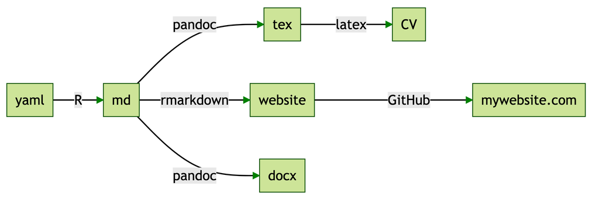

## Makefile

[Make](https://www.gnu.org/software/make/)

```bash
all: my_pubs.docx my_cv.pdf site

pubs.md talks.md: pubs.yaml talks.yaml
        R CMD BATCH parse.R

my_pubs.docx: pubs.md
        pandoc pubs.md --reference-doc=reference.dotx -o my_pubs.docx

cv.pdf: pubs.tex talks.tex cv.tex
        texfot pdflatex cv.tex

site: pubs.md talks.md cv.pdf
        R -e "rmarkdown::render_site(encoding = 'UTF-8')"
        cp cole-brokamp-cv.pdf docs/cv.pdf
        open docs/index.html
```

## Update Your CV

1. edit `pubs.yaml` and `talks.yaml`
2. `make all`
3. (commit & push)

## Applications

- [Website](https://github.com/cole-brokamp/colebrokamp.com)
- [NIH biosketch](https://github.com/cole-brokamp/biosketch)
- [NIH Other Support](https://github.com/cole-brokamp/support)

## R-Centric Alternatives

- `pandoc`: {[rmarkdown](https://rmarkdown.rstudio.com/docs/reference/pandoc_args.html)}, `system2()`
- `Make`: {[targets](https://books.ropensci.org/targets/)}
- `LaTeX`: {[TinyTeX](https://yihui.org/tinytex/)}
- `GitHub`: {[gert](https://docs.ropensci.org/gert/)}, RStudio

## Extensions

- use alternative data storage solutions (Google spreadsheets, local CSV)
- use Google Scholar, ORCID, etc. API to get publications
- automate citation creation with a PubMed/DOI API
- hosting and download of published manuscripts
- GitHub actions to automate `make`ing and deployment

## R as an interface to other tools/languages

- bottleneck for data science programming often around reading/writing (instead of executing) code
- R considered as a “user interface”
- DSL languages in R for computing on code

Automate CV with R (Cole Brokamp)